# 09_PINN_Labs_textbook

**Scientific Machine Learning:**  
**Physics-Informed Neural Networks: Labs**

Summary

## Learning Objectives

After studying this notebook, you should be able to

- assemble a PINN in PyTorch from its four parts — a network mapping the coordinate to the solution, derivatives obtained with `torch.autograd.grad`, a residual function that evaluates the governing equation on those derivatives, and a loss that adds the residual to the initial or boundary conditions;
- differentiate a network output as many times as the equation requires, and recognize that the fourth derivative in the beam equation costs four nested `grad` calls;
- turn a forward problem into an inverse one by declaring the unknown property a trainable parameter alongside the network weights, initialized far from its true value so that agreement is earned rather than assumed;
- explain, and demonstrate, why the physics and the boundary conditions alone may fail to identify that parameter, and why a handful of observations is enough to fix it;
- decide where to place the sensors, from the sensitivity of the solution to the unknown parameter;
- weight a data term against the physics terms, and say what goes wrong when their scales do not match;
- reparameterize a positive unknown as $\log\theta$, and constrain a bounded output with a sigmoid;
- estimate two unknown properties at once in a non-linear, two-dimensional system, and read their traces rather than their final values to decide whether the estimates can be trusted;
- recover an entire unknown boundary condition instead of a scalar, and write a qualitative piece of prior knowledge, “constant but unknown”, as a variance penalty computed from the network's own output;
- read a PINN result critically — which part of the domain is supported by data, which by the equation alone, and which by neither.

> **Where we are going.** The theory behind everything used here — why the physics enters through the loss function, what the collocation points are for, and how the terms of a composite loss interact — is developed in **Physics-informed Neural Networks (PINN)**. This notebook is the practice. Five problems from five different fields are each carried to the identification of something unknown — a stiffness, a discharge coefficient, two epidemic rates, the density and viscosity of a fluid, and an entire missing boundary condition — with every line of the implementation written out. Read the chapters as variations on one recipe: only the residual function and the list of trainable tensors really change.

# 1. Simply Supported Beam

## 1.1. The Problem

This chapter returns to the Euler beam of **Physics-informed Neural Networks (PINN)**, Section 5, and rebuilds it from nothing: no library, every derivative taken by hand with `torch.autograd.grad`, and the problem carried through to the identification of an unknown stiffness.

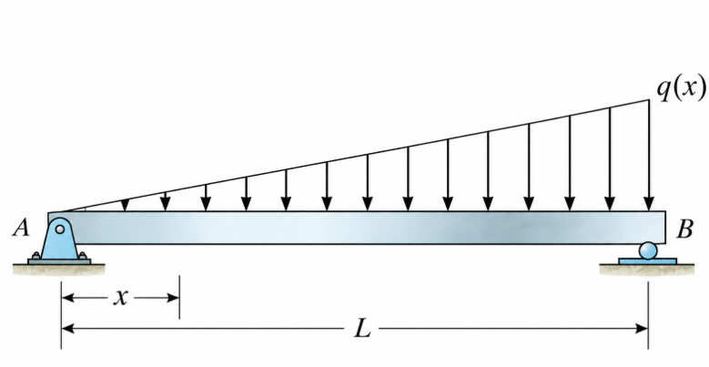

### 1.1.1. Governing Equation

For an Euler-Bernoulli beam, the transverse displacement $y(x)$ satisfies

$$ EI\frac{d^4y}{dx^4}+q(x)=0. $$

In this example,

$$ E=1,\qquad I=1,\qquad L=1, $$

and the distributed load is

$$ q(x)=x. $$

Therefore, the governing equation becomes

$$ \frac{d^4y}{dx^4}+x=0, \qquad x\in[0,1]. $$

Each derivative of $y$ carries a physical name — slope, bending moment, shear force, and finally the load — so this single fourth-order equation is four familiar statements stacked on top of one another. It is also what makes the beam a demanding first test for a PINN: before the equation can even be evaluated, the network's output has to be differentiated four times.

### 1.1.2. Problem Setup

- Problem properties

$$ E=1,\qquad I=1,\qquad L=1 $$

- Governing differential equation

$$ y''''(x)+x=0, \qquad x\in[0,1] $$

- Simply supported boundary conditions

$$ y(0)=0,\qquad y''(0)=0 $$

$$ y(1)=0,\qquad y''(1)=0 $$

- Quantities of interest

$$ \theta(x)=y'(x),\qquad M(x)=EIy''(x),\qquad V(x)=EIy'''(x) $$

**Simply supported** means that each end rests on a support which holds it in place but does not resist rotation. The displacement is therefore zero there, and so is the bending moment. That is two conditions at each end, four in all — exactly the number a fourth-order equation requires.

## 1.2. Lab 1: Forward Problem

**Import Library**

Everything here is plain PyTorch: a network from `torch.nn`, derivatives from `torch.autograd`, an optimizer from `torch.optim`. No PINN library is involved, so every term of the loss stays visible.

```python
import numpy as np
import torch
import torch.nn as nn
import matplotlib.pyplot as plt
```

**Set the Random Seed**

The weights are initialized randomly, so a fixed seed is what makes a run repeatable.

```python
np.random.seed(0)
torch.manual_seed(0)
```

```
<torch._C.Generator at 0x77d654140cd0>
```

```python
device = torch.device('cuda:0' if torch.cuda.is_available() else 'cpu')
print(device)
```

```
cuda:0
```

**Define Collocation Points**

The PDE residual is evaluated at 25 evenly spaced points over

$$ x\in[0,1]. $$

The two endpoints are also used to enforce the simply supported boundary conditions.

A collocation point is not a measurement. It is simply a location at which the network will be **asked** to satisfy the differential equation; the value of $y$ there is unknown and is never supplied. This is the precise sense in which a PINN can be trained without data.

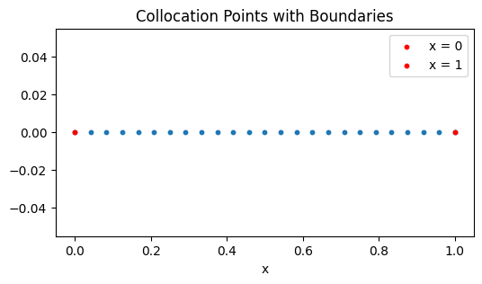

```python
x_pts = np.linspace(0, 1, 25)

plt.figure(figsize = (6, 3))
plt.scatter(x_pts, np.zeros_like(x_pts), s = 10)
plt.scatter(0, 0, label = 'x = 0', s = 10, c = 'red')
plt.scatter(1, 0, label = 'x = 1', s = 10, c = 'red')
plt.xlabel('x')
plt.legend()
plt.title('Collocation Points with Boundaries')
plt.show()
```

**Define Network and Hyper-parameters**

The neural network takes the coordinate $x$ as input and predicts the transverse displacement $y(x)$.

It is an ordinary fully connected network, and nothing in the method depends on its size; every loss term will be a mean squared residual.

```python
class PINN(nn.Module):
    def __init__(self):
        super(PINN, self).__init__()
        self.net = nn.Sequential(
            nn.Linear(1, 32),
            nn.Tanh(),
            nn.Linear(32, 32),
            nn.Tanh(),
            nn.Linear(32, 32),
            nn.Tanh(),
            nn.Linear(32, 32),
            nn.Tanh(),
            nn.Linear(32, 1)
        )

    def forward(self, x):
        return self.net(x)

model = PINN().to(device)
optimizer = torch.optim.Adam(model.parameters(), lr = 1e-3)
```

**Define Functions to Compute Physics Loss**

`derivative` is the whole of automatic differentiation for our purposes. It differentiates `y` with respect to `x`, and because `create_graph = True` the result is itself differentiable, so calling it again gives the second derivative, and again the third. Any tensor it differentiates with respect to must have been created with `requires_grad = True`.

```python
def derivative(y, x):
    return torch.autograd.grad(y, x, grad_outputs = torch.ones_like(y), create_graph = True)[0]
```

**Define PDE System**

The governing equation is

$$ \frac{d^4y}{dx^4}+x=0, \qquad x\in[0,1]. $$

Therefore, the PDE residual is

$$ r(x)=y''''(x)+x. $$

In code this is four nested calls to `derivative`, each differentiating the previous result. The function returns the residual; turning it into a single number to minimize is the job of the training loop.

```python
def PDE(model, x):
    y = model(x)
    y_x = derivative(y, x)
    y_xx = derivative(y_x, x)
    y_xxx = derivative(y_xx, x)
    y_xxxx = derivative(y_xxx, x)

    pde = y_xxxx + x
    return pde
```

**Define Boundary Condition**

For a simply supported beam,

$$ y(0)=0, \qquad y''(0)=0, $$

$$ y(1)=0, \qquad y''(1)=0. $$

Each end contributes two residuals, the displacement and the second derivative, both of which should vanish. They come from the same `derivative` helper, now applied at the single point $x = 0$ or $x = 1$.

```python
def BC_left(model, x_0):
    y_0 = model(x_0)
    y_x_0 = derivative(y_0, x_0)
    y_xx_0 = derivative(y_x_0, x_0)

    bc1 = y_0
    bc2 = y_xx_0

    return bc1, bc2

def BC_right(model, x_1):
    y_1 = model(x_1)
    y_x_1 = derivative(y_1, x_1)
    y_xx_1 = derivative(y_x_1, x_1)

    bc3 = y_1
    bc4 = y_xx_1

    return bc3, bc4
```

**Train**

The total loss combines the governing-equation residual and the boundary-condition errors:

$$ \mathcal{L} = \mathcal{L}_{PDE} + \mathcal{L}_{BC}. $$

There is nothing in the loop that an ordinary training loop does not have. Five quantities are driven towards zero — the PDE residual at the collocation points and the four boundary residuals — and their mean squared values are simply added. Note what is missing: no measured displacement appears anywhere. The network is being fitted to an equation, not to data.

```python
x = torch.tensor(x_pts.reshape(-1, 1), dtype = torch.float32, requires_grad = True).to(device)
x0 = torch.tensor([[0.0]], requires_grad = True).to(device)
x1 = torch.tensor([[1.0]], requires_grad = True).to(device)

for epoch in range(2001):
    pde_term = PDE(model, x)
    bc1, bc2 = BC_left(model, x0)
    bc3, bc4 = BC_right(model, x1)

    loss_pde = torch.mean(pde_term**2)
    loss_bc = torch.mean(bc1**2) + torch.mean(bc2**2) + torch.mean(bc3**2) + torch.mean(bc4**2)

    loss = loss_pde + loss_bc

    optimizer.zero_grad()
    loss.backward()
    optimizer.step()

    if epoch % 500 == 0:
        print(
            'Epoch: {} Loss: {:.6f} PDELoss: {:.6f} BCLoss: {:.6f}'.format(
                epoch,
                loss.item(),
                loss_pde.item(),
                loss_bc.item()
            )
        )
```

```
Epoch: 0 Loss: 0.467405 PDELoss: 0.280504 BCLoss: 0.186901
Epoch: 500 Loss: 0.000032 PDELoss: 0.000031 BCLoss: 0.000000
Epoch: 1000 Loss: 0.000017 PDELoss: 0.000017 BCLoss: 0.000000
Epoch: 1500 Loss: 0.000012 PDELoss: 0.000012 BCLoss: 0.000000
Epoch: 2000 Loss: 0.000008 PDELoss: 0.000008 BCLoss: 0.000000
```

**Define Exact Solution**

The analytical solution is used only for validation after training.

Integrating $y'''' = -x$ four times and imposing the four support conditions gives a closed form, so the PINN can be judged against the truth rather than against its own loss. The derivatives are written out as well, because the slope, moment and shear are what an engineer actually asks for.

```python
def exact_displacement(x):
    return -x ** 5 / 120 + x ** 3 / 36 - 7 * x / 360

def exact_slope(x):
    return -x ** 4 / 24 + x ** 2 / 12 - 7 / 360

def exact_moment(x):
    return -x ** 3 / 6 + x / 6

def exact_shear(x):
    return -x ** 2 / 2 + 1 / 6
```

**Result**

The trained PINN is evaluated on 100 points and compared with the analytical solution for displacement, slope, bending moment, and shear force.

Each of the four is one more derivative of the same network output, so read them as four increasingly severe tests of a single fit.

**Compute Predicted Quantities**

The same derivative calls used during training are reused here, with the results detached to NumPy for plotting.

```python
def predict_quantities(model, x_test):
    x_tensor = torch.tensor(x_test.reshape(-1, 1), dtype = torch.float32, requires_grad = True).to(device)

    y = model(x_tensor)
    y_x = derivative(y, x_tensor)
    y_xx = derivative(y_x, x_tensor)
    y_xxx = derivative(y_xx, x_tensor)

    displacement = y.detach().cpu().numpy().flatten()
    slope = y_x.detach().cpu().numpy().flatten()
    moment = y_xx.detach().cpu().numpy().flatten()          # EI y'' with EI = 1
    shear = y_xxx.detach().cpu().numpy().flatten()          # EI y''' with EI = 1

    return displacement, slope, moment, shear
```

**Define Test Points**

The hundred test points are finer than the twenty-five used for training. The network is a continuous function of $x$, so it can be evaluated anywhere, including at points it never saw.

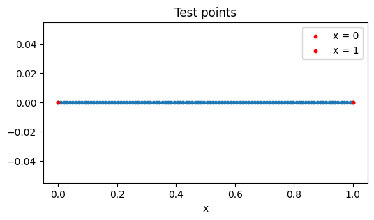

```python
x_test = np.linspace(0, 1, 100)

plt.figure(figsize = (6, 3))
plt.scatter(x_test, np.zeros_like(x_test), s = 10)
plt.scatter(0, 0, label = 'x = 0', s = 10, c = 'red')
plt.scatter(1, 0, label = 'x = 1', s = 10, c = 'red')
plt.xlabel('x')
plt.legend()
plt.title('Test points')
plt.show()
```

```python
y, slope, moment, shear = predict_quantities(model, x_test)
```

**Displacement**

The displacement is the network's own output and the quantity the boundary conditions act on directly, so it is the easiest of the four to get right.

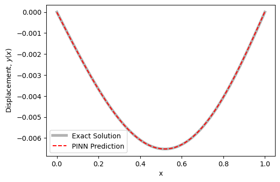

```python
# plot displacement (prediction vs exact solution)
plt.figure(figsize=(6, 4))

plt.plot(x_test, exact_displacement(x_test), 'k', lw = 4, label='Exact Solution', alpha=0.3)
plt.plot(x_test, y, 'r--', label='PINN Prediction')

plt.xlabel('x')
plt.ylabel(r'Displacement, $y(x)$')
plt.legend()

plt.show()
```

**Slope**

One derivative away from the output. Nothing in the loss compares the slope with the exact solution; the agreement comes from the residual alone.

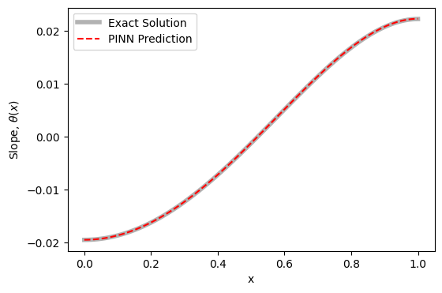

```python
plt.figure(figsize=(6, 4))

plt.plot(x_test, exact_slope(x_test), "k", lw=4, label="Exact Solution", alpha=0.3)
plt.plot(x_test, slope, "r--", label="PINN Prediction")

plt.xlabel("x")
plt.ylabel(r"Slope, $\theta(x)$")
plt.legend()
plt.show()
```

**Bending Moment**

Two derivatives away. $M = EIy''$ is the quantity a designer checks against an allowable stress, so it matters that it is right in the interior and not only at the supports.

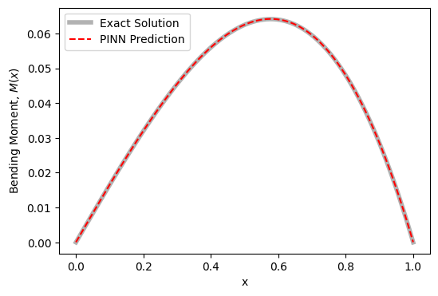

```python
plt.figure(figsize=(6, 4))

plt.plot(x_test, exact_moment(x_test), "k", lw = 4, label="Exact Solution", alpha=0.3)
plt.plot(x_test, moment, "r--", label="PINN Prediction")

plt.xlabel("x")
plt.ylabel(r"Bending Moment, $M(x)$")
plt.legend()
plt.show()
```

**Shear Force**

Three derivatives away, and still on top of the exact solution. That is a stronger statement than the picture suggests: $y'''$ never appears in the loss, so its accuracy is inherited entirely from the equation the network was made to satisfy.

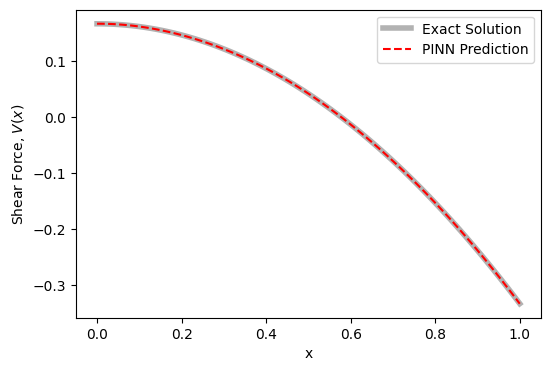

```python
plt.figure(figsize=(6, 4))

plt.plot(x_test, exact_shear(x_test), "k", lw = 4, label="Exact Solution", alpha=0.3)
plt.plot(x_test, shear, "r--", label="PINN Prediction")

plt.xlabel("x")
plt.ylabel(r"Shear Force, $V(x)$")
plt.legend()
plt.show()
```

## 1.3. Lab 2: Inverse Problem without Observed Data

### 1.3.1. Problem Setup

The beam stiffness is now unknown. We keep the second moment of area fixed at

$$I=1$$

and learn Young's modulus,

$$\color{red}{E=\;?}$$

from the beam equation

$$E I y^{(4)}(x)+x=0$$

and the same simply supported boundary conditions. The true value is $E=1$, but no displacement observations are included in this example.

$E$ is initialized at $0.5$ and optimized jointly with the network weights.

### 1.3.2. Solve the Inverse Problem

**Define Physics Loss with Unknown Young's Modulus**

The residual is the one from Lab 1 with a single change: $E$ arrives as an argument instead of being the constant $1$. Because it is a tensor that requires a gradient, the derivative of the loss with respect to $E$ comes for free, exactly as it does for the network weights.

```python
def inverse_PDE(model, x, E):
    y = model(x)

    y_x = derivative(y, x)
    y_xx = derivative(y_x, x)
    y_xxx = derivative(y_xx, x)
    y_xxxx = derivative(y_xxx, x)

    # E*I times the fourth derivative of y + q(x) = 0
    pde = E * y_xxxx + x

    return pde
```

**Define Network and Unknown Parameter**

`E` is created as a one-element tensor and handed to Adam in the same parameter list as the weights. From the optimizer's point of view it is simply one more number to adjust.

```python
torch.manual_seed(1)

model_inverse_no_data = PINN().to(device)
E_no_data = torch.tensor([0.5], device = device, requires_grad = True)

x_inverse = torch.tensor(x_pts.reshape(-1, 1), dtype = torch.float32, requires_grad = True).to(device)
x0_inverse = torch.tensor([[0.0]], requires_grad = True).to(device)
x1_inverse = torch.tensor([[1.0]], requires_grad = True).to(device)

optimizer = torch.optim.Adam([
    {'params': model_inverse_no_data.parameters(), 'lr': 1e-3},
    {'params': E_no_data, 'lr': 1e-3}
])
```

**Train Using Only Physics and Boundary Conditions**

$$ \mathcal{L} = \mathcal{L}_{PDE} + \mathcal{L}_{BC} $$

The loss is identical to Lab 1. Only the list of unknowns has grown by one.

```python
E_no_data_list = []

for epoch in range(3001):

    pde_term = inverse_PDE(model_inverse_no_data, x_inverse, E_no_data)
    bc1, bc2 = BC_left(model_inverse_no_data, x0_inverse)
    bc3, bc4 = BC_right(model_inverse_no_data, x1_inverse)

    loss_pde = torch.mean(pde_term**2)
    loss_bc = torch.mean(bc1**2) + torch.mean(bc2**2) + torch.mean(bc3**2) + torch.mean(bc4**2)

    loss = loss_pde + loss_bc

    optimizer.zero_grad()
    loss.backward()
    optimizer.step()

    E_no_data_list.append(E_no_data.item())

    if epoch % 500 == 0:
        print(f'Epoch: {epoch} Loss: {loss.item():.6f} '
              f'PDELoss: {loss_pde.item():.6f} '
              f'BCLoss: {loss_bc.item():.6f} E: {E_no_data.item():.4f}')
```

```
Epoch: 0 Loss: 0.367081 PDELoss: 0.318478 BCLoss: 0.048603 E: 0.5010
Epoch: 500 Loss: 0.000012 PDELoss: 0.000012 BCLoss: 0.000000 E: 0.5666
Epoch: 1000 Loss: 0.000045 PDELoss: 0.000009 BCLoss: 0.000036 E: 0.5672
Epoch: 1500 Loss: 0.000109 PDELoss: 0.000018 BCLoss: 0.000091 E: 0.5675
Epoch: 2000 Loss: 0.000001 PDELoss: 0.000001 BCLoss: 0.000000 E: 0.5680
Epoch: 2500 Loss: 0.000001 PDELoss: 0.000001 BCLoss: 0.000000 E: 0.5686
Epoch: 3000 Loss: 0.000001 PDELoss: 0.000001 BCLoss: 0.000000 E: 0.5696
```

**Result**

The inverse problem is underdetermined: physics and boundary conditions alone do not identify Young's modulus.

```
True E: 1.0000, Estimated E without data: 0.5696
```

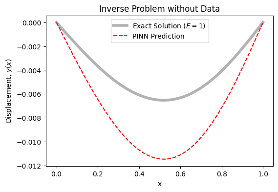

```python
x_test_inverse = np.linspace(0, 1, 100)
x_test_tensor = torch.tensor(x_test_inverse.reshape(-1, 1), dtype = torch.float32).to(device)

y_no_data = model_inverse_no_data(x_test_tensor).detach().cpu().numpy().flatten()

print(f"True E: 1.0000, Estimated E without data: {E_no_data.item():.4f}\n\n")

plt.figure(figsize=(6, 4))
plt.plot(x_test_inverse, exact_displacement(x_test_inverse),
         "k", lw = 4, label="Exact Solution ($E=1$)", alpha=0.3)
plt.plot(x_test_inverse, y_no_data, "r--", label="PINN Prediction")
plt.xlabel("x")
plt.ylabel(r"Displacement, $y(x)$")
plt.title("Inverse Problem without Data")
plt.legend()
plt.show()
```

## 1.4. Lab 3: Inverse Problem with Observed Data

### 1.4.1. Define Observed Data

We now add nine displacement observations generated from the analytical solution with the true value $E=1$. Interior points are used because the displacement is fixed at zero at both supports and those endpoint values provide no information about the stiffness. The trainable modulus is initialized at $E=0.2$, well away from its true value.

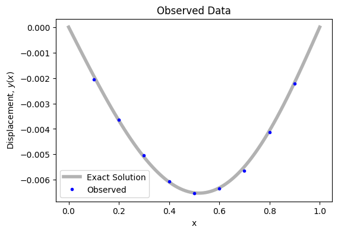

```python
x_obs = np.linspace(0.1, 0.9, 9).reshape(-1, 1)
y_obs = exact_displacement(x_obs) + 0.0001*np.random.randn(*x_obs.shape)

plt.figure(figsize=(6, 4))
plt.plot(x_test_inverse, exact_displacement(x_test_inverse),
         'k', lw = 4, label='Exact Solution', alpha=0.3)
plt.plot(x_obs, y_obs, 'bo', markersize=3, label='Observed')
plt.xlabel('x')
plt.ylabel(r'Displacement, $y(x)$')
plt.title('Observed Data')
plt.legend()
plt.show()
```

### 1.4.2. Solve the Inverse Problem

**Define Data-Driven Loss Term**

The displacement values are small for this nondimensional beam, so the data loss is weighted by $1000$ to keep it comparable with the PDE and boundary-condition losses.

$$ \mathcal{L} = \mathcal{L}_{PDE} + \mathcal{L}_{BC} + 1000\mathcal{L}_{DATA} $$

```python
torch.manual_seed(2)

model_inverse_data = PINN().to(device)
E_data = torch.tensor([0.2], device = device, requires_grad = True)

optimizer = torch.optim.Adam([
    {'params': model_inverse_data.parameters(), 'lr': 1e-3},
    {'params': E_data, 'lr': 1e-3}
])

x_data = torch.tensor(x_obs, dtype = torch.float32).to(device)
y_data = torch.tensor(y_obs, dtype = torch.float32).to(device)
```

**Train**

Three terms now, and the data term is the only one that has ever seen a displacement value.

```python
lambda_data = 1000

E_data_list = []
loss_list = []

for epoch in range(3001):

    pde_term = inverse_PDE(model_inverse_data, x_inverse, E_data)
    bc1, bc2 = BC_left(model_inverse_data, x0_inverse)
    bc3, bc4 = BC_right(model_inverse_data, x1_inverse)

    loss_pde = torch.mean(pde_term**2)
    loss_bc = torch.mean(bc1**2) + torch.mean(bc2**2) + torch.mean(bc3**2) + torch.mean(bc4**2)
    loss_data = torch.mean((model_inverse_data(x_data) - y_data)**2)

    loss = loss_pde + loss_bc + lambda_data*loss_data

    optimizer.zero_grad()
    loss.backward()
    optimizer.step()

    E_data_list.append(E_data.item())
    loss_list.append(loss.item())

    if epoch % 500 == 0:
        print(f'Epoch: {epoch} Loss: {loss.item():.6f} '
              f'PDELoss: {loss_pde.item():.6f} '
              f'BCLoss: {loss_bc.item():.6f} '
              f'DATALoss: {loss_data.item():.6f} E: {E_data.item():.4f}')
```

```
Epoch: 0 Loss: 14.294443 PDELoss: 0.348714 BCLoss: 0.025370 DATALoss: 0.013920 E: 0.1990
Epoch: 500 Loss: 0.059761 PDELoss: 0.032027 BCLoss: 0.020581 DATALoss: 0.000007 E: 0.7716
Epoch: 1000 Loss: 0.008055 PDELoss: 0.003439 BCLoss: 0.003480 DATALoss: 0.000001 E: 0.9632
Epoch: 1500 Loss: 0.002539 PDELoss: 0.001916 BCLoss: 0.000492 DATALoss: 0.000000 E: 1.0282
Epoch: 2000 Loss: 0.073270 PDELoss: 0.001544 BCLoss: 0.000186 DATALoss: 0.000072 E: 1.0699
Epoch: 2500 Loss: 0.000696 PDELoss: 0.000606 BCLoss: 0.000084 DATALoss: 0.000000 E: 1.1086
Epoch: 3000 Loss: 0.000369 PDELoss: 0.000316 BCLoss: 0.000047 DATALoss: 0.000000 E: 1.1388
```

**Total Loss History**

Worth remembering while reading it: in Lab 2 the loss also fell smoothly, and the answer was still wrong. A small loss reports self-consistency, not correctness.

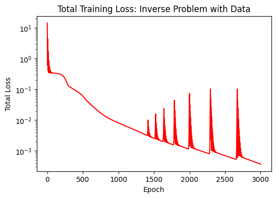

```python
plt.figure(figsize=(6, 4))
plt.semilogy(loss_list, c='r')
plt.xlabel('Epoch')
plt.ylabel('Total Loss')
plt.title('Total Training Loss: Inverse Problem with Data')
plt.show()
```

**Refine with L-BFGS**

Adam moves every parameter by a fixed step scaled by its running gradient average. Once the loss is small that step is too large for the sharpest directions, so the loss spikes late in training and $E$ keeps drifting past its true value. L-BFGS uses curvature and a line search, which is why PINNs are commonly trained with Adam first and L-BFGS last. The closure recomputes the loss and its gradient at every trial point. L-BFGS decides each step by comparing loss values along a line search. Near $10^{-5}$ those differences fall below what single precision can resolve, so the refinement runs in double precision.

```python
n_adam = len(loss_list)

model_inverse_data.double()
E_data = E_data.detach().double().requires_grad_(True)
x_inverse = x_inverse.double()
x0_inverse, x1_inverse = x0_inverse.double(), x1_inverse.double()
x_data, y_data = x_data.double(), y_data.double()

optimizer = torch.optim.LBFGS(list(model_inverse_data.parameters()) + [E_data],
                              lr=1.0, max_iter=1000, max_eval=2000,
                              history_size=50, tolerance_change=0,
                              tolerance_grad=1e-9,
                              line_search_fn='strong_wolfe')

def closure():
    optimizer.zero_grad()

    pde_term = inverse_PDE(model_inverse_data, x_inverse, E_data)
    bc1, bc2 = BC_left(model_inverse_data, x0_inverse)
    bc3, bc4 = BC_right(model_inverse_data, x1_inverse)

    loss_pde = torch.mean(pde_term**2)
    loss_bc = torch.mean(bc1**2) + torch.mean(bc2**2) + torch.mean(bc3**2) + torch.mean(bc4**2)
    loss_data = torch.mean((model_inverse_data(x_data) - y_data)**2)

    loss = loss_pde + loss_bc + lambda_data*loss_data
    loss.backward()

    E_data_list.append(E_data.item())
    loss_list.append(loss.item())
    return loss

optimizer.step(closure)

print(f'L-BFGS evaluations: {len(loss_list) - n_adam} Loss: {loss_list[-1]:.6f} E: {E_data.item():.4f}')
```

```
L-BFGS evaluations: 1326 Loss: 0.000011 E: 1.0207
```

**Total Loss History with L-BFGS**

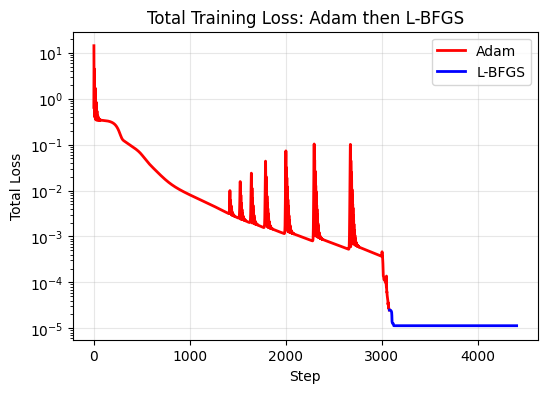

```python
loss_lbfgs = np.array(loss_list[n_adam:])
best = np.minimum.accumulate(loss_lbfgs)
keep = np.concatenate(([True], np.diff(best) < 0))
step = np.arange(n_adam, len(loss_list))

plt.figure(figsize=(6, 4))
plt.semilogy(range(n_adam), loss_list[:n_adam], c='r', linewidth=2, label='Adam')
plt.semilogy(step[keep], loss_lbfgs[keep], c='b', linewidth=2, label='L-BFGS')
plt.xlabel('Step')
plt.ylabel('Total Loss')
plt.title('Total Training Loss: Adam then L-BFGS')
plt.legend()
plt.grid(alpha=0.3)
plt.show()
```

**Result**

```
True E: 1.0000, Estimated E with data: 1.0207
```

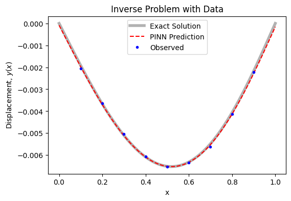

```python
y_with_data = model_inverse_data(x_test_tensor.double()).detach().cpu().numpy().flatten()

print(f'True E: 1.0000, Estimated E with data: {E_data.item():.4f}\n\n')

plt.figure(figsize=(6, 4))
plt.plot(x_test_inverse, exact_displacement(x_test_inverse),
         'k', lw = 4, label='Exact Solution', alpha=0.3)
plt.plot(x_test_inverse, y_with_data, 'r--', label='PINN Prediction')
plt.plot(x_obs, y_obs, 'bo', markersize=3, label='Observed')
plt.xlabel('x')
plt.ylabel(r'Displacement, $y(x)$')
plt.title('Inverse Problem with Data')
plt.legend()
plt.show()
```

The displacement observations fix the response scale. The network can no longer compensate for an arbitrary value of $E$ by rescaling $y(x)$, so Young's modulus becomes identifiable and is recovered jointly with the displacement field.

# 2. Unsteady Drainage of a Tank

## 2.1. The Problem

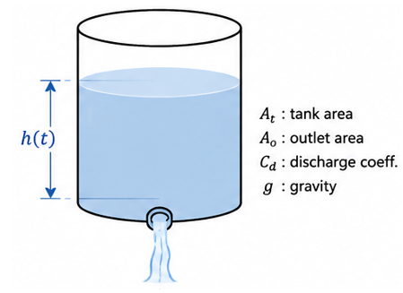

- $h(t)$ : water level at time t
- $A_t$ : tank cross-sectional area
- $A_o$ : outlet area
- $C_d$ : discharge coefficient
- $g$ : acceleration of gravity

An open tank is filled with water to an initial level. A small orifice at the bottom lets the water out. The higher the water level, the faster the water leaves; as water leaves, the level drops; as the level drops, the outflow slows down again.

That feedback is what makes this a differential equation.

### 2.1.1. Governing Equation

Mass conservation for the water in the tank states that the rate of change of the stored volume equals minus the outflow rate. **Torricelli's law** gives the outflow velocity: the water leaving the orifice moves as fast as if it had fallen freely from the free surface,

$$gh = \frac{1}{2}v^2 \quad \Longrightarrow \quad v = \sqrt{2gh}$$

This form assumes the free surface itself is essentially at rest, which holds when the tank is much wider than the orifice, $A_o \ll A_t$.

In practice the jet contracts (vena contracta) and friction takes a further toll, so less comes out. That loss is lumped into a single discharge coefficient $C_d$ (about $0.6$ for a sharp-edged orifice). Writing $A_t$ for the tank cross-section and $A_o$ for the orifice area,

$$A_t \frac{dh}{dt} = -C_d A_o \sqrt{2gh}$$

We collect the four constants into one,

$$C = \frac{C_d A_o \sqrt{2g}}{A_t}$$

so that the problem carries a single number. The equation is a **first-order, nonlinear ODE**, and it comes with an **initial condition**, not a boundary condition.

$$\frac{dh}{dt} = -C\sqrt{h}$$

### 2.1.2. Problem Setup

- Problem properties (nondimensionalized)

$$C = 1$$

- Ordinary differential equation

$$\frac{dh}{dt} = -C\sqrt{h}, \qquad \text{where} \quad t \in [0, 2]$$

- One initial condition

$$h(0) = 1$$

- The exact solution

$$ h(t) = \begin{cases} \left(1 - \frac{Ct}{2}\right)^2 \quad & \text{for } t \le \frac{2}{C} \\ \\ 0 &\text{after that} \end{cases} $$

### 2.1.3. Three Labs

| Lab | Setting | Question |
| --- | --- | --- |
| 1 | $C$ is known | Can a PINN reproduce the exact solution? |
| 2 | $C$ is unknown, no data | Can the physics alone pin down $C$? |
| 3 | $C$ is unknown, a few measurements | Can physics and data together recover $C$? |

Lab 2 and Lab 3 are **inverse problems**: we solve for the solution and for an unknown property of the system at the same time.

## 2.2. Lab 1: Forward Problem

**Import Library**

The same imports as the beam. Nothing in the method changes when the physics does.

```python
import numpy as np
import torch
import torch.nn as nn
import matplotlib.pyplot as plt
```

**Set the Random Seed**

Here the seed fixes both the weights and the collocation points, which are redrawn at every training iteration.

```python
np.random.seed(0)
torch.manual_seed(0)
```

```
<torch._C.Generator at 0x72ec73f20cd0>
```

```python
device = torch.device('cuda:0' if torch.cuda.is_available() else 'cpu')
print(device)
```

```
cuda:0
```

**Define Collocation Points**

The ODE residual is evaluated at 100 points sampled uniformly from

$$ t\in[0,2]. $$

The points are redrawn at every training iteration, which is a small but real difference from the beam lab: the equation is enforced at a different random set of instants every time, so the network cannot satisfy the residual by learning a fixed grid of points.

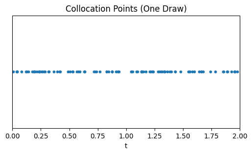

```python
t_train = np.random.rand(100, 1) * 2

plt.figure(figsize = (6, 3))
plt.scatter(t_train, np.zeros_like(t_train), s = 10)
plt.xlim([0, 2])
plt.yticks([])
plt.xlabel('t')
plt.title('Collocation Points (One Draw)')
plt.show()
```

**Define Network and Hyper-parameters**

The neural network takes time $t$ as input and predicts the water level $h(t)$.

The architecture is unchanged from the beam — four hidden layers of $32$ $\tanh$ units — which is itself worth noticing. It was not retuned for a different equation in a different field; only the residual function was rewritten.

```python
class PINN(nn.Module):
    def __init__(self):
        super(PINN, self).__init__()
        self.net = nn.Sequential(
            nn.Linear(1, 32),
            nn.Tanh(),
            nn.Linear(32, 32),
            nn.Tanh(),
            nn.Linear(32, 32),
            nn.Tanh(),
            nn.Linear(32, 32),
            nn.Tanh(),
            nn.Linear(32, 1)
        )

    def forward(self, t):
        return self.net(t)

model = PINN().to(device)
optimizer = torch.optim.Adam(model.parameters(), lr = 1e-3)
```

**Define Functions to Compute Physics Loss**

Identical to the beam's helper, and this time only one derivative is ever needed.

```python
def derivative(y, t):
    return torch.autograd.grad(y, t, grad_outputs = torch.ones_like(y), create_graph = True)[0]
```

**Define ODE System**

The governing equation is

$$ \frac{dh}{dt}+C\sqrt{h}=0. $$

The clamp and the small offset inside the square root are a practical detail rather than part of the mathematics: $\sqrt{h}$ is undefined for negative $h$, and an untrained network will cheerfully predict one in its first few iterations, which would turn the residual into `NaN`.

```python
def ODE(model, t, C):
    h = model(t)
    h_t = derivative(h, t)

    ode = h_t + C * torch.sqrt(torch.clamp(h, min = 0.0) + 1e-8)
    return ode
```

**Define Initial Condition**

The initial condition is

$$ h(0)=1. $$

A first-order equation needs exactly one condition, and unlike the beam it is imposed at a single instant rather than at two ends.

```python
def IC(model, t_0):
    h_0 = model(t_0)
    return h_0
```

**Train**

The total loss combines the ODE residual and the initial-condition error:

$$ \mathcal{L} = \mathcal{L}_{ODE} + \mathcal{L}_{IC}. $$

No measured level appears anywhere: the network is fitted to the equation at the freshly drawn points and to the single value $h(0) = 1$.

```python
C = 1.0
t_0 = torch.zeros((1, 1), requires_grad = True).to(device)

for epoch in range(5001):
    t = torch.tensor(np.random.rand(100, 1)*2, dtype = torch.float32, requires_grad = True).to(device)

    ode_term = ODE(model, t, C)
    ic_term = IC(model, t_0)

    loss_ode = torch.mean(ode_term**2)
    loss_ic = torch.mean((ic_term - 1)**2)

    loss = loss_ode + loss_ic

    optimizer.zero_grad()
    loss.backward()
    optimizer.step()

    if epoch % 500 == 0:
        print(
            'Epoch: {} Loss: {:.6f} ODELoss: {:.6f} ICLoss: {:.6f}'.format(
                epoch,
                loss.item(),
                loss_ode.item(),
                loss_ic.item()
            )
        )
```

```
Epoch: 0 Loss: 0.800368 ODELoss: 0.311249 ICLoss: 0.489119
Epoch: 500 Loss: 0.001077 ODELoss: 0.001070 ICLoss: 0.000007
Epoch: 1000 Loss: 0.000814 ODELoss: 0.000810 ICLoss: 0.000004
Epoch: 1500 Loss: 0.000605 ODELoss: 0.000601 ICLoss: 0.000004
Epoch: 2000 Loss: 0.001479 ODELoss: 0.001448 ICLoss: 0.000031
Epoch: 2500 Loss: 0.000426 ODELoss: 0.000423 ICLoss: 0.000002
Epoch: 3000 Loss: 0.001050 ODELoss: 0.001050 ICLoss: 0.000000
Epoch: 3500 Loss: 0.000149 ODELoss: 0.000147 ICLoss: 0.000002
Epoch: 4000 Loss: 0.000247 ODELoss: 0.000247 ICLoss: 0.000000
Epoch: 4500 Loss: 0.000150 ODELoss: 0.000148 ICLoss: 0.000002
Epoch: 5000 Loss: 0.000190 ODELoss: 0.000177 ICLoss: 0.000012
```

**Define Exact Solution**

The analytical solution is used to validate the trained PINN.

Separating variables gives a parabola that reaches zero at $t = 2/C$, after which the tank is empty and the formula no longer applies.

```python
def exact_solution(t):
    return (1 - t / 2) ** 2
```

**Result**

The prediction should follow the parabola down to the moment the tank empties.

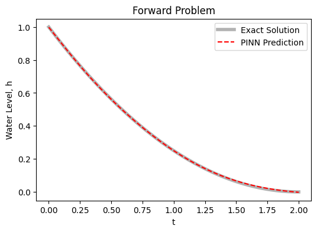

```python
t_test = np.linspace(0, 2, 100).reshape(-1, 1)
t_test_tensor = torch.tensor(t_test, dtype = torch.float32).to(device)

h_pred = model(t_test_tensor).detach().cpu().numpy()

plt.figure(figsize = (6, 4))
plt.plot(t_test, exact_solution(t_test), 'k', lw = 4, label = 'Exact Solution', alpha = 0.3)
plt.plot(t_test, h_pred, 'r--', label = 'PINN Prediction')
plt.xlabel('t')
plt.ylabel('Water Level, h')
plt.title('Forward Problem')
plt.legend()
plt.show()
```

## 2.3. Lab 2: Inverse Problem without Observed Data

### 2.3.1. Problem Setup

Now the drainage constant is not given.

- Unknown property

$$\color{red}{C = \;?}$$

- Ordinary differential equation

$$\frac{dh}{dt} = -\color{red}{C}\sqrt{h}, \qquad h(0) = 1$$

$C$ becomes a trainable parameter, optimized jointly with the network weights. It is initialized at $0.5$, away from the true value, so that any agreement at the end is earned rather than assumed.

Nothing else changes — the loss still has only the two physics terms.

### 2.3.2. Solve the Inverse Problem

**Define Network and Unknown Parameter**

A fresh network and a fresh $C$, handed to the optimizer as one more number to adjust.

```python
torch.manual_seed(0)

model_inverse_no_data = PINN().to(device)
C_no_data = torch.tensor([0.5], device = device, requires_grad = True)

optimizer = torch.optim.Adam([
    {'params': model_inverse_no_data.parameters(), 'lr': 1e-3},
    {'params': C_no_data, 'lr': 1e-3}
])
```

**Train Using Only Physics and Initial Condition**

$$ \mathcal{L} = \mathcal{L}_{ODE} + \mathcal{L}_{IC}. $$

Identical to Lab 1 except that $C$ is now optimized alongside the weights. Nothing tells the loop what $C$ ought to be.

```python
C_no_data_list = []

for epoch in range(5001):
    t = torch.tensor(np.random.rand(100, 1)*2, dtype = torch.float32, requires_grad = True).to(device)

    ode_term = ODE(model_inverse_no_data, t, C_no_data)
    ic_term = IC(model_inverse_no_data, t_0)

    loss_ODE = torch.mean(ode_term**2)
    loss_IC = torch.mean((ic_term - 1)**2)

    loss = loss_ODE + loss_IC

    optimizer.zero_grad()
    loss.backward()
    optimizer.step()

    C_no_data_list.append(C_no_data.item())

    if epoch % 500 == 0:
        print(
            'Epoch: {} Loss: {:.6f} ODELoss: {:.6f} ICLoss: {:.6f} C: {:.4f}'.format(
                epoch,
                loss.item(),
                loss_ODE.item(),
                loss_IC.item(),
                C_no_data.item()
            )
        )
```

```
Epoch: 0 Loss: 0.568279 ODELoss: 0.079161 ICLoss: 0.489119 C: 0.4990
Epoch: 500 Loss: 0.000003 ODELoss: 0.000003 ICLoss: 0.000000 C: 0.4718
Epoch: 1000 Loss: 0.000001 ODELoss: 0.000001 ICLoss: 0.000000 C: 0.4715
Epoch: 1500 Loss: 0.000001 ODELoss: 0.000001 ICLoss: 0.000000 C: 0.4713
Epoch: 2000 Loss: 0.000001 ODELoss: 0.000001 ICLoss: 0.000000 C: 0.4712
Epoch: 2500 Loss: 0.000001 ODELoss: 0.000001 ICLoss: 0.000000 C: 0.4712
Epoch: 3000 Loss: 0.000001 ODELoss: 0.000001 ICLoss: 0.000000 C: 0.4712
Epoch: 3500 Loss: 0.000000 ODELoss: 0.000000 ICLoss: 0.000000 C: 0.4712
Epoch: 4000 Loss: 0.000001 ODELoss: 0.000000 ICLoss: 0.000000 C: 0.4712
Epoch: 4500 Loss: 0.000000 ODELoss: 0.000000 ICLoss: 0.000000 C: 0.4712
Epoch: 5000 Loss: 0.000001 ODELoss: 0.000000 ICLoss: 0.000000 C: 0.4709
```

**Result**

Read the trajectory of $C$ rather than its final value: where it goes, and whether it settles anywhere near $1$.

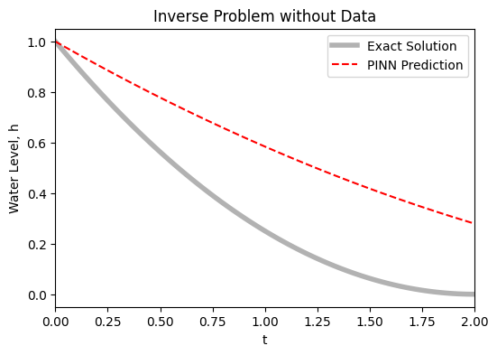

```python
h_no_data = model_inverse_no_data(t_test_tensor).detach().cpu().numpy()

plt.figure(figsize = (6, 4))
plt.plot(t_test, exact_solution(t_test), 'k', lw = 4, label = 'Exact Solution', alpha = 0.3)
plt.plot(t_test, h_no_data, 'r--', label = 'PINN Prediction')
plt.xlim([0, 2])
plt.xlabel('t')
plt.ylabel('Water Level, h')
plt.title('Inverse Problem without Data')
plt.legend()
plt.show()
```

```
True C: 1.0000, Predicted C: 0.4709
```

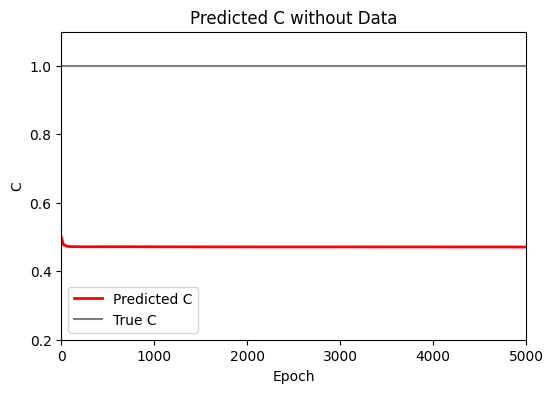

```python
print(f'True C: 1.0000, Predicted C: {C_no_data.item():.4f}\n\n')

plt.figure(figsize = (6, 4))
plt.plot(C_no_data_list, c = 'r', linewidth = 2, label = 'Predicted C')
plt.axhline(1.0, c='k', alpha = 0.5, label = 'True C')
plt.xlabel('Epoch')
plt.ylabel('C')
plt.xlim([0, 5000])
plt.ylim([0.2, 1.1])
plt.title('Predicted C without Data')
plt.legend()
plt.show()
```

## 2.4. Lab 3: Inverse Problem with Observed Data

### 2.4.1. Define Observed Data

Suppose the water level was read nine times during the experiment. The readings are generated from the exact solution with $C = 1$ and corrupted with a small amount of noise; $C$ is of course assumed to be unknown throughout this lab.

The readings are taken between $t = 0.2$ and $t = 1.6$, away from both ends of the domain. How much a reading tells us about $C$ is the sensitivity of the level to $C$,

$$\frac{\partial h}{\partial C} = -t\left(1 - \frac{Ct}{2}\right)$$

Evaluated at the true value $C = 1$, this vanishes at $t = 0$, where the level is pinned by the initial condition, and again at $t = 2$, where the tank has just emptied. It is largest in magnitude at $t = 1$. **A sensor placed at either end would carry no information about $C$**, which is why the readings sit in the middle.

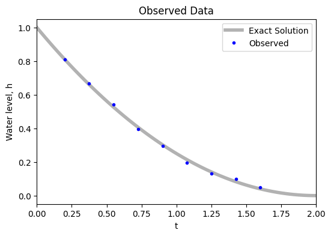

```python
t_obs = np.linspace(0.2, 1.6, 9).reshape(-1, 1)
h_obs = exact_solution(t_obs) + 0.01*np.random.randn(9, 1)

plt.figure(figsize = (6, 4))
plt.plot(t_test, exact_solution(t_test), 'k', lw = 4, label = 'Exact Solution', alpha = 0.3)
plt.plot(t_obs, h_obs, 'bo', markersize = 3, label = 'Observed')
plt.xlim([0, 2])
plt.legend()
plt.xlabel('t')
plt.ylabel('Water level, h')
plt.title('Observed Data')
plt.show()
```

### 2.4.2. Solve the Inverse Problem

**Define Data-Driven Loss Term**

$$\mathcal{L} = \mathcal{L}_{ODE} + \mathcal{L}_{IC} + \mathcal{L}_{DATA}$$

The three terms are added with equal weight. The water level is of order one, so the data term is already comparable with the others and needs no scaling — unlike the beam, whose displacements were a few thousandths and whose data term needed a factor of $1000$.

```python
torch.manual_seed(0)

model_inverse_data = PINN().to(device)
C_data = torch.tensor([0.5], device = device, requires_grad = True)

optimizer = torch.optim.Adam([
    {'params': model_inverse_data.parameters(), 'lr': 1e-3},
    {'params': C_data, 'lr': 1e-3}
])
```

```python
t_data = torch.tensor(t_obs, dtype = torch.float32).to(device)
h_data = torch.tensor(h_obs, dtype = torch.float32).to(device)
```

**Train Using Physics, Initial Condition, and Observed Data**

$$ \mathcal{L} = \mathcal{L}_{ODE} + \mathcal{L}_{IC} + \mathcal{L}_{DATA}. $$

One more term, nine more points, and no other change to the loop.

```python
C_data_list = []

for epoch in range(5001):
    t = torch.tensor(np.random.rand(100, 1)*2, dtype = torch.float32, requires_grad = True).to(device)

    ode_term = ODE(model_inverse_data, t, C_data)
    ic_term = IC(model_inverse_data, t_0)

    loss_ode = torch.mean(ode_term**2)
    loss_ic = torch.mean((ic_term - 1)**2)
    loss_data = torch.mean((model_inverse_data(t_data) - h_data)**2)

    loss = loss_ode + loss_ic + loss_data

    optimizer.zero_grad()
    loss.backward()
    optimizer.step()

    C_data_list.append(C_data.item())

    if epoch % 500 == 0:
        print(
            'Epoch: {} Loss: {:.6f} ODELoss: {:.6f} ICLoss: {:.6f} '
            'DATALoss: {:.6f} C: {:.4f}'.format(
                epoch,
                loss.item(),
                loss_ode.item(),
                loss_ic.item(),
                loss_data.item(),
                C_data.item()
            )
        )
```

```
Epoch: 0 Loss: 0.635524 ODELoss: 0.078997 ICLoss: 0.489119 DATALoss: 0.067408 C: 0.4990
Epoch: 500 Loss: 0.005722 ODELoss: 0.002216 ICLoss: 0.000841 DATALoss: 0.002664 C: 0.7802
Epoch: 1000 Loss: 0.000907 ODELoss: 0.000275 ICLoss: 0.000084 DATALoss: 0.000548 C: 0.9282
Epoch: 1500 Loss: 0.001716 ODELoss: 0.000987 ICLoss: 0.000025 DATALoss: 0.000704 C: 0.9680
Epoch: 2000 Loss: 0.000842 ODELoss: 0.000493 ICLoss: 0.000044 DATALoss: 0.000304 C: 0.9887
Epoch: 2500 Loss: 0.000923 ODELoss: 0.000772 ICLoss: 0.000005 DATALoss: 0.000145 C: 0.9911
Epoch: 3000 Loss: 0.000335 ODELoss: 0.000160 ICLoss: 0.000001 DATALoss: 0.000174 C: 0.9868
Epoch: 3500 Loss: 0.000587 ODELoss: 0.000438 ICLoss: 0.000001 DATALoss: 0.000147 C: 0.9959
Epoch: 4000 Loss: 0.000721 ODELoss: 0.000540 ICLoss: 0.000001 DATALoss: 0.000180 C: 0.9880
Epoch: 4500 Loss: 0.000300 ODELoss: 0.000168 ICLoss: 0.000000 DATALoss: 0.000132 C: 0.9942
Epoch: 5000 Loss: 0.000314 ODELoss: 0.000178 ICLoss: 0.000000 DATALoss: 0.000136 C: 0.9940
```

**Refine with L-BFGS**

Adam moves every parameter by a fixed step scaled by its running gradient average. Once the loss is small that step is too large for the sharpest directions, so the loss spikes late in training and $C$ stops short of its true value. L-BFGS uses curvature and a line search, which is why PINNs are commonly trained with Adam first and L-BFGS last. The closure recomputes the loss and its gradient at every trial point, and L-BFGS chooses each step by comparing those values along the line search. Two things follow. The collocation points are drawn once and held fixed, because a line search cannot compare losses measured on a different draw each time. And the refinement runs in double precision, because near $10^{-5}$ the differences the line search is comparing fall below what single precision can resolve.

```python
n_adam = len(C_data_list)

model_inverse_data.double()
C_data = C_data.detach().double().requires_grad_(True)
t_col = torch.tensor(np.random.rand(100, 1)*2, dtype = torch.float64, requires_grad = True).to(device)
t_0 = torch.zeros((1, 1), dtype = torch.float64, requires_grad = True).to(device)
t_data, h_data = t_data.double(), h_data.double()

optimizer = torch.optim.LBFGS(list(model_inverse_data.parameters()) + [C_data],
                              lr = 1.0, max_iter = 1000, max_eval = 2000,
                              history_size = 50, tolerance_change = 0,
                              tolerance_grad = 1e-9,
                              line_search_fn = 'strong_wolfe')

loss_list = []

def closure():
    optimizer.zero_grad()

    ode_term = ODE(model_inverse_data, t_col, C_data)
    ic_term = IC(model_inverse_data, t_0)

    loss_ode = torch.mean(ode_term**2)
    loss_ic = torch.mean((ic_term - 1)**2)
    loss_data = torch.mean((model_inverse_data(t_data) - h_data)**2)

    loss = loss_ode + loss_ic + loss_data
    loss.backward()

    C_data_list.append(C_data.item())
    loss_list.append(loss.item())
    return loss

optimizer.step(closure)

print(f'L-BFGS evaluations: {len(loss_list)} Loss: {loss_list[-1]:.6f} C: {C_data.item():.4f}')
```

```
L-BFGS evaluations: 1433 Loss: 0.000138 C: 1.0034
```

**Result**

Compare this curve of $C$ with the one from Lab 2. Same network, same equation, same optimizer; the only difference is nine numbers.

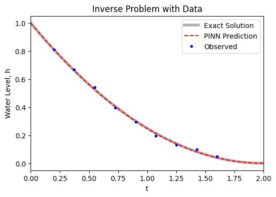

```python
h_with_data = model_inverse_data(t_test_tensor.double()).detach().cpu().numpy().flatten()

plt.figure(figsize = (6, 4))
plt.plot(t_test, exact_solution(t_test), 'k', lw = 4, label = 'Exact Solution', alpha = 0.3)
plt.plot(t_test, h_with_data, 'r--', label = 'PINN Prediction')
plt.plot(t_obs, h_obs, 'bo', markersize = 3, label = 'Observed')
plt.xlim([0, 2])
plt.xlabel('t')
plt.ylabel('Water Level, h')
plt.title('Inverse Problem with Data')
plt.legend()
plt.show()
```

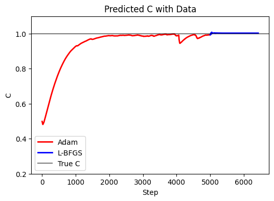

```python
best = np.minimum.accumulate(np.array(loss_list))
keep = np.concatenate(([True], np.diff(best) < 0))
step = np.arange(n_adam, len(C_data_list))
C_lbfgs = np.array(C_data_list[n_adam:])

plt.figure(figsize = (6, 4))
plt.plot(range(n_adam), C_data_list[:n_adam], c = 'r', linewidth = 2, label = 'Adam')
plt.plot(step[keep], C_lbfgs[keep], c = 'b', linewidth = 2, label = 'L-BFGS')
plt.axhline(1.0, c = 'k', alpha = 0.5, label = 'True C')
plt.xlabel('Step')
plt.ylabel('C')
plt.ylim([0.2, 1.1])
plt.title('Predicted C with Data')
plt.legend()
plt.show()
```

Nine noisy readings are enough to close the system. The same network, the same equation and one extra loss term now recover the drainage constant.

Note where the curve is least accurate. After the last reading at $t = 1.6$ there is no data left, and the solution there is held up by the equation alone — which is exactly the part of the domain the sensitivity argument told us carries no information about $C$.

Converting back to the physical coefficient is a single line,

$$C_d = \frac{C A_t}{A_o \sqrt{2g}}$$

so a value near $0.6$ would tell us the orifice is sharp-edged.

## 2.5. What the Three Labs Showed

| Lab | Loss terms | Outcome |
| --- | --- | --- |
| 1 Forward | $\mathcal{L}_{ODE} + \mathcal{L}_{IC}$ | matches the exact solution |
| 2 Inverse, no data | $\mathcal{L}_{ODE} + \mathcal{L}_{IC}$ | $C$ is not identifiable |
| 3 Inverse, with data | $\mathcal{L}_{ODE} + \mathcal{L}_{IC} + \mathcal{L}_{DATA}$ | $C$ is recovered |

A PINN solving a forward problem competes with numerical methods that are already good at it. The inverse problem is where it earns its place: the unknown property sits in the loss function as one more trainable number, and a handful of measurements is enough to find it.

# 3. SIR Epidemic Model

## 3.1. The Problem

The **SIR model** is a foundational mathematical framework in epidemiology that models the spread of an infectious disease by dividing a fixed population ($N$) into three distinct compartments over time $t$:

- **$S(t)$ (Susceptible):** Individuals who are healthy and can contract the disease.
- **$I(t)$ (Infected):** Individuals who are currently infected and capable of transmitting the disease.
- **$R(t)$ (Recovered / Removed):** Individuals who have recovered with immunity or have been removed from the transmission chain.

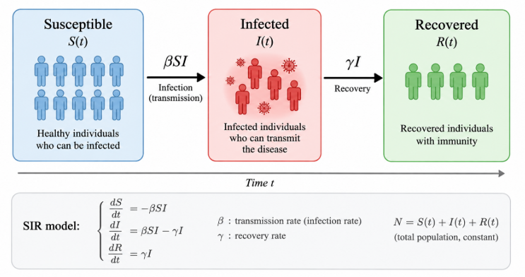

### 3.1.1. Governing Equations

The SIR model partitions a population into susceptible, infected, and recovered fractions,

$$ S(t),\qquad I(t),\qquad R(t). $$

Their evolution is governed by

$$ \frac{dS}{dt}=-\beta SI, $$

$$ \frac{dI}{dt}=\beta SI-\gamma I, $$

$$ \frac{dR}{dt}=\gamma I, $$

where $\beta$ is the transmission rate and $\gamma$ is the recovery rate.

### 3.1.2. Inverse Problem Setup

In this example, the reference parameters and initial conditions are

$$ \beta=0.30,\qquad \gamma=0.10, $$

$$ S(0)=0.99,\qquad I(0)=0.01,\qquad R(0)=0. $$

A physics-informed neural network learns $S(t)$, $I(t)$, and $R(t)$ while jointly estimating the unknown parameters $\beta$ and $\gamma$ from sparse observations of $I(t)$.

## 3.2. Lab: Joint Estimation of the Trajectory and the Parameters

**Import Libraries**

This lab has both a solver and a network in it. `scipy.integrate.solve_ivp` generates the reference epidemic, and the PINN then has to recover it from twenty noisy glimpses.

```python
import numpy as np
import matplotlib.pyplot as plt
import torch
import torch.nn as nn
from scipy.integrate import solve_ivp
```

**Set the Random Seed**

```python
np.random.seed(42)
torch.manual_seed(42)

device = torch.device("cuda" if torch.cuda.is_available() else "cpu")
print("Device:", device)
```

```
Device: cuda
```

**Define and Solve the Reference SIR System**

The reference solution is generated over

$$ t\in[0,100] $$

using a high-accuracy numerical ODE solver.

This plays the part of the real epidemic. The network never sees it — only the handful of noisy samples drawn from it — and it is kept aside so that the recovered trajectory and parameters can be checked at the end.

```python
# True SIR parameters
beta_true = 0.30
gamma_true = 0.10

# Initial conditions
S0 = 0.99
I0 = 0.01
R0 = 0.00

# Time domain
t_start = 0.0
t_end = 100.0

def sir_rhs(t, y):
    S, I, R = y

    dSdt = -beta_true * S * I
    dIdt = beta_true * S * I - gamma_true * I
    dRdt = gamma_true * I

    return [dSdt, dIdt, dRdt]

# Dense time grid for ground truth
t_true = np.linspace(t_start, t_end, 500)
solution = solve_ivp(sir_rhs, [t_start, t_end], [S0, I0, R0], t_eval=t_true)

S_true = solution.y[0]
I_true = solution.y[1]
R_true = solution.y[2]
```

**Plot the Reference Solution**

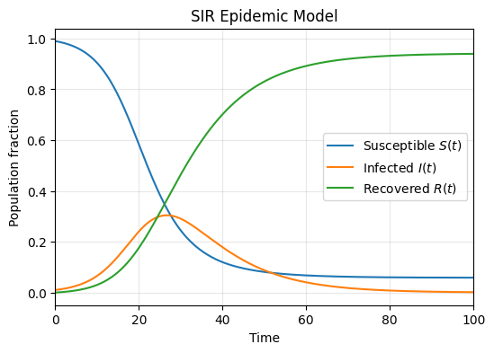

```python
plt.figure(figsize=(6, 4))

plt.plot(t_true, S_true, label="Susceptible $S(t)$")
plt.plot(t_true, I_true, label="Infected $I(t)$")
plt.plot(t_true, R_true, label="Recovered $R(t)$")

plt.xlabel("Time")
plt.ylabel("Population fraction")
plt.title("SIR Epidemic Model")
plt.legend()
plt.grid(alpha=0.3)
plt.xlim([0, 100])
plt.show()
```

**Create Sparse Epidemiological Observations**

Twenty infected-population observations are sampled across the time interval. Small Gaussian measurement noise is added to emulate observed epidemiological data.

Only the infected fraction is observed, which is realistic: case counts are reported, while the susceptible and recovered fractions are not measured. $S(t)$ and $R(t)$ must therefore be inferred from the equations alone, and that is the interesting part of this lab.

```python
n_obs = 20
obs_idx = np.linspace(0, len(t_true) - 1, n_obs, dtype=int)
t_obs = t_true[obs_idx]
I_obs = I_true[obs_idx]

# Add small measurement noise
noise_std = 0.002
I_obs_noisy = I_obs + noise_std * np.random.randn(n_obs)
I_obs_noisy = np.clip(I_obs_noisy, 0.0, 1.0)
```

**Plot the Sparse Observations**

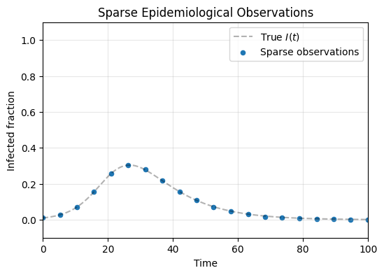

```python
plt.figure(figsize=(6, 4))

plt.plot(t_true, I_true, 'k--', label="True $I(t)$", alpha = 0.3)
plt.scatter(t_obs, I_obs_noisy, s = 20, label="Sparse observations")

plt.xlabel("Time")
plt.ylabel("Infected fraction")
plt.title("Sparse Epidemiological Observations")
plt.legend()
plt.grid(alpha=0.3)
plt.xlim([0, 100])
plt.ylim([-0.1, 1.1])
plt.show()
```

**Define Network and Hyper-parameters**

The network takes time $t$ as input and predicts all three state variables:

$$ t\longmapsto \bigl(\hat S(t),\hat I(t),\hat R(t)\bigr). $$

A sigmoid output constrains each predicted population fraction to $[0,1]$. The logarithms of $\beta$ and $\gamma$ are optimized so that both learned parameters remain positive.

```python
class SIR_PINN(nn.Module):
    def __init__(self):
        super().__init__()
        self.net = nn.Sequential(
            nn.Linear(1, 64),
            nn.Tanh(),
            nn.Linear(64, 64),
            nn.Tanh(),
            nn.Linear(64, 64),
            nn.Tanh(),
            nn.Linear(64, 3)
        )

    def forward(self, t):
        # Scale time approximately to [-1, 1]
        t_scaled = 2.0 * (t - t_start) / (t_end - t_start) - 1.0
        raw = self.net(t_scaled)
        # Keep S, I, R positive
        y = torch.sigmoid(raw)
        S = y[:, 0:1]
        I = y[:, 1:2]
        R = y[:, 2:3]

        return S, I, R

model = SIR_PINN().to(device)
log_beta = nn.Parameter(torch.tensor(np.log(0.2), dtype=torch.float32, device=device))
log_gamma = nn.Parameter(torch.tensor(np.log(0.2), dtype=torch.float32, device=device))
```

**Define Functions to Compute Physics Loss**

The same `derivative` as in the earlier chapters.

```python
def derivative(y, x):
    return torch.autograd.grad(y, x, grad_outputs = torch.ones_like(y), create_graph = True)[0]
```

**Define SIR Physics Residuals**

Automatic differentiation provides the time derivatives of the network outputs. The SIR residuals are

$$ f_S=\frac{d\hat S}{dt}+\beta\hat S\hat I, $$

$$ f_I=\frac{d\hat I}{dt}-\beta\hat S\hat I+\gamma\hat I, $$

$$ f_R=\frac{d\hat R}{dt}-\gamma\hat I. $$

An ideal physics-consistent solution satisfies

$$ f_S=f_I=f_R=0. $$

```python
def physics_residual(model, t, beta, gamma):
    S, I, R = model(t)

    dSdt = derivative(S, t)
    dIdt = derivative(I, t)
    dRdt = derivative(R, t)

    # SIR residuals
    f_S = dSdt + beta * S * I
    f_I = dIdt - beta * S * I + gamma * I
    f_R = dRdt - gamma * I

    return f_S, f_I, f_R
```

**Define Collocation Points**

The physics residuals are evaluated at 200 evenly spaced collocation points over the full time interval.

Two hundred points for a hundred-day interval, against twenty observations. The equations are enforced everywhere; the data speak only at twenty instants.

```python
n_collocation = 200

t_f = torch.tensor(np.linspace(t_start, t_end, n_collocation).reshape(-1, 1),
                   dtype = torch.float32, requires_grad = True).to(device)
```

```python
# Observation and initial-condition tensors
t_obs_t = torch.tensor(t_obs[:, None], dtype=torch.float32, device=device)

I_obs_t = torch.tensor(I_obs_noisy[:, None], dtype=torch.float32, device=device)

t0_t = torch.tensor([[0.0]], dtype=torch.float32, device=device)

initial_state = torch.tensor([[S0, I0, R0]], dtype=torch.float32, device=device)
```

**Train**

The network weights and the two epidemiological parameters are optimized jointly with Adam. The total loss combines sparse-data agreement, the governing equations, the initial conditions, and population conservation:

$$ \mathcal{L} =10\mathcal{L}_{DATA} +\mathcal{L}_{PHYSICS} +10\mathcal{L}_{IC} +\mathcal{L}_{MASS}. $$

The conservation term encourages

$$ \hat S(t)+\hat I(t)+\hat R(t)=1. $$

```python
optimizer = torch.optim.Adam(list(model.parameters()) + [log_beta, log_gamma], lr=1e-3)
lambda_data = 10.0
lambda_ic = 10.0

epochs = 10000
loss_history = []

for epoch in range(epochs):
    beta = torch.exp(log_beta)
    gamma = torch.exp(log_gamma)

    # Data loss: sparse infected observations
    _, I_pred_obs, _ = model(t_obs_t)
    loss_data = torch.mean((I_pred_obs - I_obs_t)**2)

    # Physics loss: SIR residuals at the collocation points
    f_S, f_I, f_R = physics_residual(model, t_f, beta, gamma)
    loss_physics = torch.mean(f_S**2) + torch.mean(f_I**2) + torch.mean(f_R**2)

    # Initial-condition loss
    S_pred0, I_pred0, R_pred0 = model(t0_t)
    loss_ic = torch.mean((S_pred0 - S0)**2) + torch.mean((I_pred0 - I0)**2) + torch.mean((R_pred0 - R0)**2)

    # Population-conservation loss
    S_f, I_f, R_f = model(t_f)
    loss_mass = torch.mean((S_f + I_f + R_f - 1)**2)

    loss = (lambda_data * loss_data + loss_physics + lambda_ic * loss_ic + loss_mass)

    optimizer.zero_grad()
    loss.backward()
    optimizer.step()

    loss_history.append(loss.item())

    if epoch % 1000 == 0:
        beta_est = torch.exp(log_beta).item()
        gamma_est = torch.exp(log_gamma).item()

        print(
            f"Epoch {epoch:5d} | "
            f"Loss: {loss.item():.3e} | "
            f"Data: {loss_data.item():.3e} | "
            f"Physics: {loss_physics.item():.3e} | "
            f"beta: {beta_est:.4f} | "
            f"gamma: {gamma_est:.4f}"
        )
```

```
Epoch     0 | Loss: 1.043e+01 | Data: 1.923e-01 | Physics: 1.608e-02 | beta: 0.1998 | gamma: 0.1998
Epoch  1000 | Loss: 1.561e-02 | Data: 3.113e-04 | Physics: 6.280e-04 | beta: 0.1039 | gamma: 0.1616
Epoch  2000 | Loss: 6.779e-04 | Data: 1.716e-05 | Physics: 3.542e-04 | beta: 0.0787 | gamma: 0.0959
Epoch  3000 | Loss: 3.432e-04 | Data: 5.104e-06 | Physics: 2.374e-04 | beta: 0.0546 | gamma: 0.0666
Epoch  4000 | Loss: 2.359e-04 | Data: 2.527e-06 | Physics: 1.833e-04 | beta: 0.0413 | gamma: 0.0495
Epoch  5000 | Loss: 1.858e-04 | Data: 1.648e-06 | Physics: 1.542e-04 | beta: 0.0331 | gamma: 0.0381
Epoch  6000 | Loss: 1.586e-04 | Data: 1.385e-06 | Physics: 1.358e-04 | beta: 0.0282 | gamma: 0.0302
Epoch  7000 | Loss: 1.394e-04 | Data: 1.300e-06 | Physics: 1.207e-04 | beta: 0.0273 | gamma: 0.0249
Epoch  8000 | Loss: 1.213e-04 | Data: 1.132e-06 | Physics: 1.063e-04 | beta: 0.0353 | gamma: 0.0228
Epoch  9000 | Loss: 1.201e-04 | Data: 1.949e-06 | Physics: 9.751e-05 | beta: 0.0512 | gamma: 0.0274
```

**Refine with L-BFGS**

```python
n_adam = len(loss_history)

model.double()
log_beta = nn.Parameter(log_beta.detach().double())
log_gamma = nn.Parameter(log_gamma.detach().double())
t_obs_t, I_obs_t, t0_t, t_f = t_obs_t.double(), I_obs_t.double(), t0_t.double(), t_f.double()

optimizer = torch.optim.LBFGS(list(model.parameters()) + [log_beta, log_gamma],
                              lr=1.0, max_iter=1000, max_eval=2000, history_size=50,
                              tolerance_change=0, tolerance_grad=1e-9,
                              line_search_fn="strong_wolfe")

def closure():
    optimizer.zero_grad()

    beta = torch.exp(log_beta)
    gamma = torch.exp(log_gamma)

    # Data loss: sparse infected observations
    _, I_pred_obs, _ = model(t_obs_t)
    loss_data = torch.mean((I_pred_obs - I_obs_t)**2)

    # Physics loss: SIR residuals at the collocation points
    f_S, f_I, f_R = physics_residual(model, t_f, beta, gamma)
    loss_physics = torch.mean(f_S**2) + torch.mean(f_I**2) + torch.mean(f_R**2)

    # Initial-condition loss
    S_pred0, I_pred0, R_pred0 = model(t0_t)
    loss_ic = torch.mean((S_pred0 - S0)**2) + torch.mean((I_pred0 - I0)**2) + torch.mean((R_pred0 - R0)**2)

    # Population-conservation loss
    S_f, I_f, R_f = model(t_f)
    loss_mass = torch.mean((S_f + I_f + R_f - 1)**2)

    loss = (lambda_data * loss_data + loss_physics
            + lambda_ic * loss_ic + loss_mass)
    loss.backward()

    loss_history.append(loss.item())
    return loss

optimizer.step(closure)

beta_est = torch.exp(log_beta).item()
gamma_est = torch.exp(log_gamma).item()

print(
    f"L-BFGS evaluations: {len(loss_history) - n_adam} | "
    f"Loss: {loss_history[-1]:.3e} | "
    f"beta: {beta_est:.4f} | "
    f"gamma: {gamma_est:.4f}"
)
```

```
L-BFGS evaluations: 1082 | Loss: 3.458e-06 | beta: 0.2970 | gamma: 0.0995
```

**Total Loss History**

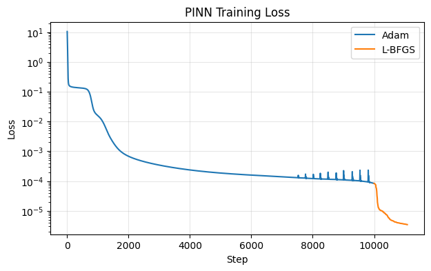

```python
loss_lbfgs = np.array(loss_history[n_adam:])
best = np.minimum.accumulate(loss_lbfgs)
keep = np.concatenate(([True], np.diff(best) < 0))
step = np.arange(n_adam, len(loss_history))

plt.figure(figsize=(7, 4))

plt.semilogy(range(n_adam), loss_history[:n_adam], label="Adam")
plt.semilogy(step[keep], loss_lbfgs[keep], label="L-BFGS")

plt.xlabel("Step")
plt.ylabel("Loss")
plt.title("PINN Training Loss")
plt.legend()
plt.grid(alpha=0.3)

plt.show()
```

**Results**

The trained network is evaluated at the reference time points, and the learned positive parameters are recovered from their logarithmic representation.

```python
t_test_t = torch.tensor(t_true[:, None], dtype=torch.float64, device=device)

with torch.no_grad():
    S_pred, I_pred, R_pred = model(t_test_t)

S_pred = S_pred.cpu().numpy().flatten()
I_pred = I_pred.cpu().numpy().flatten()
R_pred = R_pred.cpu().numpy().flatten()

beta_est = torch.exp(log_beta).item()
gamma_est = torch.exp(log_gamma).item()
```

**Compare the True and Estimated Parameters**

The basic reproduction number is

$$ R_0=\frac{\beta}{\gamma}. $$

$R_0$ is the number of new infections caused by one infected individual in a fully susceptible population: above one the epidemic grows, below one it dies out. It is the quantity an epidemiologist actually wants, and it follows from the two learned parameters.

```python
print(f"True beta      : {beta_true:.4f}")
print(f"Estimated beta : {beta_est:.4f}")
print()
print(f"True gamma      : {gamma_true:.4f}")
print(f"Estimated gamma : {gamma_est:.4f}")
print()
print(f"True R0         : {beta_true / gamma_true:.3f}")
print(f"Estimated R0    : {beta_est / gamma_est:.3f}")
```

```
True beta      : 0.3000
Estimated beta : 0.2970

True gamma      : 0.1000
Estimated gamma : 0.0995

True R0         : 3.000
Estimated R0    : 2.983
```

**Compare the Predicted and Reference Solutions**

The learned trajectories are compared with the numerical reference solution, while the sparse infected-population observations show the data available during training.

Check the two unobserved curves in particular. Nothing in the data constrained $S$ or $R$ at any time; whatever agreement they show was supplied by the residuals and the conservation term.

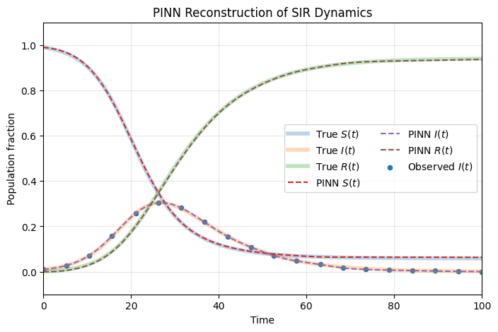

```python
plt.figure(figsize=(8, 5))

# Ground truth
plt.plot(t_true, S_true, lw = 4, label="True $S(t)$", alpha = 0.3)
plt.plot(t_true, I_true, lw = 4, label="True $I(t)$", alpha = 0.3)
plt.plot(t_true, R_true, lw = 4, label="True $R(t)$", alpha = 0.3)

# PINN predictions
plt.plot(t_true, S_pred, "--", label="PINN $S(t)$")
plt.plot(t_true, I_pred, "--", label="PINN $I(t)$")
plt.plot(t_true, R_pred, "--", label="PINN $R(t)$")

# Sparse observations
plt.scatter(t_obs, I_obs_noisy, s = 20, label="Observed $I(t)$")

plt.xlabel("Time")
plt.ylabel("Population fraction")
plt.title("PINN Reconstruction of SIR Dynamics")
plt.legend(ncol=2)
plt.grid(alpha=0.3)
plt.xlim([0, 100])
plt.ylim([-0.1, 1.1])
plt.show()
```

## 3.3. What the Lab Showed

| Component | Role |
| --- | --- |
| Sparse infected observations | constrain $\hat I(t)$ at measured times |
| SIR residuals | enforce the governing equations throughout the domain |
| Initial-condition loss | anchors $\hat S(0)$, $\hat I(0)$, and $\hat R(0)$ |
| Population-conservation loss | encourages $\hat S+\hat I+\hat R=1$ |
| Trainable $\beta$ and $\gamma$ | identify the transmission and recovery rates |

The inverse PINN combines limited observations with the SIR equations to reconstruct the full epidemic trajectory and estimate the governing parameters.

# 4. Flow Past a Cylinder

**Overview**

The three chapters so far identified one unknown constant in a one-dimensional problem. This chapter keeps the arrangement and raises the difficulty on every axis: the domain is two-dimensional with a hole in it, the equations are the non-linear Navier-Stokes system acting on three coupled fields, and two properties are unknown instead of one. We are given a flow around a cylinder, we are given the *form* of the equations governing it, and we are told that the density and the viscosity of the fluid are unknown. Seventeen sensor readings are available. Find the fluid properties, and the flow field with them.

Section 3 in **Physics-informed Neural Networks (PINN)** argued that this requires no new algorithm, only a longer decision vector, and this laboratory is where the claim is cashed. Two scalars are created as trainable tensors and handed to the optimizer alongside the network parameters; nothing else in the training loop changes. The two scalars are then estimated to within about one percent from measurements at seventeen points, which is less than a tenth of one percent of the domain.

It is worth appreciating in advance how much harder this problem would be by classical means. A conventional identification would wrap an optimization around a CFD solver: guess $\rho$ and $\mu$, solve the flow, compare against the sensors, adjust, and repeat, paying for a full flow solution at every iteration and needing derivatives of the solution with respect to the parameters, which must be obtained by finite differencing or by a separately derived adjoint. Here the flow field and the parameters descend together in one loop.

## 4.1. The Problem

The geometry is a channel with a circular cylinder in it, and the flow through it is steady and laminar. Three fields are unknown, the two velocity components and the pressure, and so are two properties of the fluid.

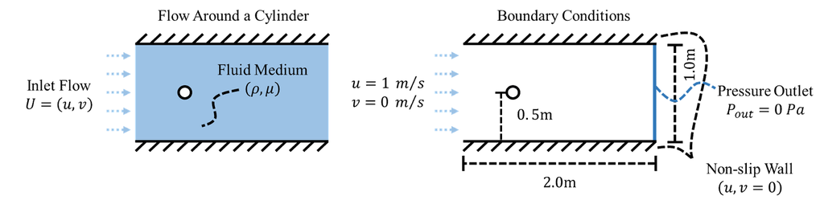

**Unknown properties**

$$\rho = ? \quad \mu = ?$$

The density and the dynamic viscosity are the quantities to be identified. The data used here was generated by a CFD computation with $\rho = 1$ and $\mu = 0.01$, and those values are recorded in the code so that the estimates can be scored afterwards. Throughout the training they are treated as completely unknown, and both are initialized at $1$, so the viscosity begins a factor of one hundred away from its true value.

Since the inlet speed is $1$ and the cylinder has radius $0.05$ and hence diameter $D = 0.1$, the Reynolds number of the true flow is

$$ \mathrm{Re} = \frac{\rho U D}{\mu} = \frac{(1)(1)(0.1)}{0.01} = 10, $$

or $100$ if the channel height of $1$ is used as the length scale instead. Either way the flow is firmly laminar and there is no vortex shedding, which is what makes it legitimate to look for a steady solution with no time variable at all.

**Governing equations and boundary conditions**

$$ \color{red}\rho\left(u\frac{\partial u}{\partial x} + v\frac{\partial u}{\partial y} + \frac{1}{\color{red}\rho}\frac{\partial p}{\partial x} \right) - \color{red}\mu\left( \frac{\partial^2u}{\partial^2 x} + \frac{\partial^2u}{\partial^2 y}\right) = 0$$

$$ \color{red}\rho\left(u\frac{\partial v}{\partial x} + v\frac{\partial v}{\partial y} + \frac{1}{\color{red}\rho}\frac{\partial p}{\partial y} \right) - \color{red}\mu\left( \frac{\partial^2v}{\partial^2 x} + \frac{\partial^2v}{\partial^2 y}\right) = 0$$

These are the steady momentum equations, with the unknown parameters marked in red. Reading them term by term: $\rho(u\,\partial u/\partial x + v\,\partial u/\partial y)$ is the convective acceleration, the rate at which a fluid particle's momentum changes because it is being carried into a region of different velocity; $\partial p/\partial x$ is the pressure gradient driving the flow; and $\mu \nabla^2 u$ is the viscous diffusion of momentum. The equations say that these three balance.

Notice the algebraic detail that the factor $1/\rho$ inside the bracket cancels the $\rho$ outside it, so the pressure gradient enters with coefficient exactly $1$. The unknown $\rho$ therefore multiplies the convective term only, and $\mu$ the viscous term only. This is not a cosmetic point and Section 4.2 returns to it, because it determines what can and cannot be identified from the measurements.

- Inlet boundary condition ($x=-0.5$):

$$u|_{x = -0.5} = 1$$

- Outlet boundary condition ($x=1.5$):

$$v|_{x = 1.5} = 0$$

$$p|_{x = 1.5} = 0$$

- Non-slip boundary condition ($y=\pm 0.5$):

$$u|_{y = \pm 0.5} = 0$$

$$v|_{y = \pm 0.5} = 0$$

The physical readings are worth naming. At the inlet the fluid arrives with a uniform speed of $1$ in the $x$-direction and none in $y$. At the outlet the flow is required to leave straight, $v=0$, and the pressure is fixed at zero, which is a datum rather than a physical statement: only pressure *differences* drive an incompressible flow, so the pressure field is determined by the equations only up to an additive constant, and one boundary value must be nominated to remove that freedom. At the channel walls and on the cylinder surface the no-slip condition applies: a viscous fluid does not slide along a solid boundary, so both velocity components vanish there.

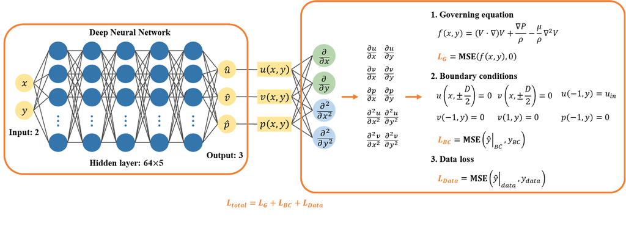

## 4.2. Lab: Estimating the Density and the Viscosity

**Import Library**

The imports are as before, with the addition of the two true parameter values, retained purely for scoring. They are never used in the loss.

```python
import numpy as np
import torch
import torch.nn as nn
import matplotlib.pyplot as plt

# true values
C1true = 1.0
C2true = 0.01

device = torch.device('cuda:0' if torch.cuda.is_available() else 'cpu')
print(device)
```

```
cuda:0
```

**Load the Data**

Two files are loaded: the coordinates of the CFD mesh points and the corresponding flow variables. (The files are not distributed with this material; the cells of this lab that depend on them are shown with the outputs of the original run.)

- [lab3_XY_domain](https://drive.google.com/file/d/1KNAg7B4Lkj3ql9oVcNO7MYz1bnl8q4SR/view?usp=drive_link)
- [lab3_gt_domain](https://drive.google.com/file/d/1fuQsD0kgqfbQO6Y1pCV08vMmJwiL4MT7/view?usp=drive_link)

The printed shapes are $(19692, 2)$ and $(19692, 3)$: nearly twenty thousand points, each with two coordinates and three field values, namely the two velocity components and the pressure. The coordinates will serve as collocation points for the equation residual, which is a legitimate use of the file since only the geometry is being taken from it. The field values are the ground truth, and all but seventeen of them are withheld from training.

```python
!gdown 1KNAg7B4Lkj3ql9oVcNO7MYz1bnl8q4SR -O /content/lab3_XY_domain.npy
!gdown 1fuQsD0kgqfbQO6Y1pCV08vMmJwiL4MT7 -O /content/lab3_gt_domain.npy
```

```
Downloading...
From: https://drive.google.com/uc?id=1KNAg7B4Lkj3ql9oVcNO7MYz1bnl8q4SR
To: /content/lab3_XY_domain.npy
100% 315k/315k [00:00<00:00, 114MB/s]
Downloading...
From: https://drive.google.com/uc?id=1fuQsD0kgqfbQO6Y1pCV08vMmJwiL4MT7
To: /content/lab3_gt_domain.npy
100% 473k/473k [00:00<00:00, 87.7MB/s]
```

```python
Y_domain = np.load('/content/lab3_XY_domain.npy')
gt_domain = np.load('/content/lab3_gt_domain.npy')
print(Y_domain.shape)
print(gt_domain.shape)
```

```
(19692, 2)
(19692, 3)
```

**Define Collocation Points**

The boundary point sets are constructed by hand, one per physical surface, and the cylinder is covered by sampling the angle around it.

The cylinder illustrates a real advantage of the mesh-free formulation. A curved boundary in a finite volume code requires a body-fitted mesh, or a cut-cell treatment, or an immersed boundary method, each of which is a substantial piece of engineering. Here the curved boundary is a list of parametric coordinates, and the no-slip condition is imposed at those coordinates by the same mean squared error used everywhere else. Geometry that is difficult to mesh is not difficult to sample.

```python
# Boundary Conditions
bc_top_x = np.linspace(-0.5, 1.5, 200).reshape(-1, 1)
bc_top_y = 0.5 * np.ones_like(bc_top_x).reshape(-1, 1)

bc_bottom_x = np.linspace(-0.5, 1.5, 200).reshape(-1, 1)
bc_bottom_y = -0.5 * np.ones_like(bc_bottom_x).reshape(-1, 1)

bc_inlet_y = np.linspace(-0.5, 0.5, 100).reshape(-1, 1)
bc_inlet_x = -0.5 * np.ones_like(bc_inlet_y).reshape(-1, 1)

bc_outlet_y = np.linspace(-0.5, 0.5, 100).reshape(-1, 1)
bc_outlet_x = 1.5 * np.ones_like(bc_outlet_y).reshape(-1, 1)

Y_top = np.concatenate((bc_top_x, bc_top_y), 1)
Y_bottom = np.concatenate((bc_bottom_x, bc_bottom_y), 1)
Y_inlet = np.concatenate((bc_inlet_x, bc_inlet_y), 1)
Y_outlet = np.concatenate((bc_outlet_x, bc_outlet_y), 1)

radius = 0.05
theta = np.linspace(0, 2 * np.pi, 200)
bc_cylinder_x = (0 + radius * np.cos(theta)).reshape(-1, 1)
bc_cylinder_y = (0 + radius * np.sin(theta)).reshape(-1, 1)
Y_cylinder = np.concatenate((bc_cylinder_x, bc_cylinder_y), 1)

Y_wall = np.concatenate((Y_top, Y_bottom, Y_cylinder))
```

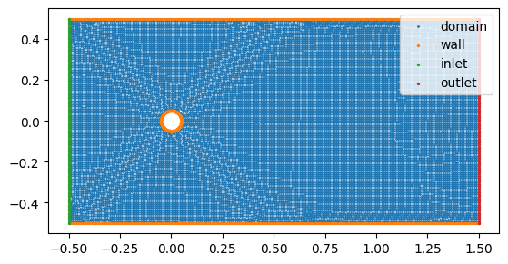

```python
plt.scatter(Y_domain[:, 0], Y_domain[:, 1], s = 1, label = 'domain')
plt.scatter(Y_wall[:, 0], Y_wall[:, 1], s = 2, label = 'wall')
plt.scatter(Y_inlet[:, 0], Y_inlet[:, 1], s = 2, label = 'inlet')
plt.scatter(Y_outlet[:, 0], Y_outlet[:, 1], s = 2, label = 'outlet')
plt.axis('scaled')
plt.legend(loc = 'upper right')
plt.show()
```

**Define Observation Points**

- This CFD data is where the density $\rho$ is 1 and the viscosity $\mu$ is 0.01.
- Of course, these two values are assumed to be unknown throughout this example.
- Also, assume that 17 sensor locations are used.
- Assume that x-velocity, y-velocity, and pressure are available at these locations.

The placement is deliberate rather than random: twelve sensors on a rectangular lattice spanning the channel, and five on a ring just outside the cylinder, each moved to the nearest node of the CFD mesh.

The arrangement is worth a moment's thought, because it is a small piece of experimental design. The lattice samples the free stream and the wake; the ring concentrates five of the seventeen sensors, nearly a third of the budget, in the annulus immediately around the cylinder where the velocity gradients are largest and therefore where the viscous term $\mu(u_{xx}+u_{yy})$ is largest. Since $\mu$ can only be identified from places where the viscous term is not negligible, spending a third of the sensors there is exactly the right instinct. PINN: Limitations and Overcoming Strategies returns to this idea in its general form.

```
Y obs: (17, 2)
GT obs: (17, 3)
```

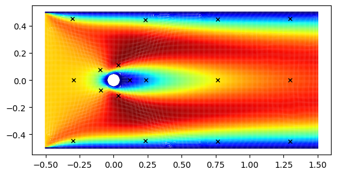

```python
x = np.linspace(-0.3, 1.3, 4)
y = np.linspace(-0.45, 0.45, 3)

xy = np.meshgrid(x, y)
XY = np.concatenate([xy[0].reshape(-1, 1), xy[1].reshape(-1, 1)], axis = 1)

theta = np.linspace(0,  2 * np.pi, 6)[:-1]

x_e = (radius + 0.07) * np.cos(theta)
y_e = (radius + 0.07) * np.sin(theta)
XY_e = np.concatenate([x_e.reshape(-1, 1), y_e.reshape(-1, 1)], axis = 1)

XY = np.concatenate([XY, XY_e], axis = 0)

diff = np.expand_dims(Y_domain, 0) - np.expand_dims(XY, 1)
dists = np.linalg.norm(diff, axis=2)
idx_obs = np.argmin(dists, axis = 1)

Y_obs = Y_domain[idx_obs]
gt_obs = gt_domain[idx_obs]
print('Y obs: {}'.format(Y_obs.shape))
print('GT obs: {}\n\n'.format(gt_obs.shape))

plt.scatter(Y_domain[:, 0], Y_domain[:, 1], c = gt_domain[:, 0], s = 1, cmap = 'jet')
plt.scatter(Y_obs[:, 0], Y_obs[:, 1], marker = 'x', linewidths = 1, s = 20, c = 'k')
plt.axis('scaled')
plt.show()
```

The printed shapes confirm the selection: seventeen sensor coordinates and seventeen triples of ground truth. Consider what that means as a quantity of information. The unknowns are a network with a few hundred thousand parameters plus two physical constants, and the entire observational input is seventeen triples, fewer than one point in a thousand of the domain. No purely data-driven method could do anything with this. The reason the problem is nevertheless tractable is that the equation residual constrains the network at all $19692$ collocation points, and it is the sensors' job only to select among the fields the equations permit, and to pin down the two constants.

The plot overlays the sensor locations as black crosses on the true $x$-velocity field, and both the lattice and the ring around the cylinder are visible in it.

**Define PINN Network**

The network maps the two coordinates to three outputs, $u$, $v$ and $p$. It is considerably larger than the plate network of Section 6 in **Physics-informed Neural Networks (PINN)**, reflecting a harder problem: a non-linear system of three coupled equations on a domain with a hole in it.

Predicting the pressure with the same network that predicts the velocities is the natural choice here, since the momentum equations couple all three fields at every point.

The plotting helper shows the $x$-velocity against the CFD reference, with their difference, and traces the estimated density and viscosity against iteration.

Those two parameter traces are the most informative diagnostic in this laboratory, and it is worth knowing how to read them. A parameter estimate that is still moving steadily has not converged, whatever the loss is doing; one that has flattened onto a horizontal line has converged, and the value it has flattened onto is the estimate. A trace that oscillates without settling indicates that the learning rate is too large for that parameter, or that the parameter is not identifiable from the available information, which is a possibility examined directly below.

```python
class PINN(nn.Module):
    def __init__(self):
        super(PINN, self).__init__()
        self.net = nn.Sequential(
            nn.Linear(2, 256),
            nn.Tanh(),
            nn.Linear(256, 256),
            nn.Tanh(),
            nn.Linear(256, 256),
            nn.Tanh(),
            nn.Linear(256, 256),
            nn.Tanh(),
            nn.Linear(256, 3)
        )
        for m in self.net:
            if isinstance(m, nn.Linear):
                nn.init.xavier_normal_(m.weight)
                nn.init.zeros_(m.bias)

    def forward(self, x):
        output = self.net(x)
        v1, v2, p = output[:, 0:1], output[:, 1:2], output[:, 2:3]
        return v1, v2, p
```

```python
from IPython.display import clear_output

def PLOT(model, Y_domain, rho_list, vis_list):
    v1, _, _ = model(Y_domain)
    xy = Y_domain.detach().cpu().numpy()
    v1 = v1.detach().cpu().numpy()

    plt.figure(figsize = (9, 2))
    plt.subplot(1, 3, 1)
    plt.title('CFD')
    plt.scatter(xy[:, 0], xy[:, 1], c = gt_domain[:, 0], s = 0.1, cmap = 'jet')
    plt.axis('scaled')

    plt.subplot(1, 3, 2)
    plt.title('Prediction')
    plt.scatter(xy[:, 0], xy[:, 1], c = v1, s = 0.1, cmap = 'jet')
    plt.axis('scaled')

    plt.subplot(1, 3, 3)
    plt.title('Error')
    plt.scatter(xy[:, 0], xy[:, 1], c = np.abs(v1 - gt_domain[:, 0:1]), s = 0.1, cmap = 'jet')
    plt.axis('scaled')
    plt.tight_layout()
    plt.show()

    plt.figure(figsize = (6, 2))
    plt.subplot(1, 2, 1)
    plt.title('Rho Prediction')
    plt.plot(rho_list)

    plt.subplot(1, 2, 2)
    plt.title('Vis Prediction')
    plt.plot(vis_list)
    plt.tight_layout()
    plt.show()
    clear_output(wait = True)
```

**Define Functions to Compute Physics Loss**

The helper is identical to that of Section 6 in **Physics-informed Neural Networks (PINN)**: the derivative function returns both partial derivatives of a scalar field.

```python
def derivative(y, t):
    df = torch.autograd.grad(y, t, grad_outputs = torch.ones_like(y), create_graph = True)[0]
    df_x = df[:, 0:1]
    df_y = df[:, 1:2]
    return df_x, df_y
```

**Define PDE**

The two-dimensional steady Navier-Stokes system, in the form the code implements:

$$ \begin{align*} \rho \left(u{\partial u \over \partial x} + v{\partial u \over \partial y} + {1 \over \rho}{\partial p \over \partial x}\right) - \mu \ \left({\partial^2 u \over {\partial x^2}} + {\partial^2 u \over {\partial y^2}}\right) &= 0\\\\ \rho \left(u{\partial v \over \partial x} + v{\partial v \over \partial y} + {1 \over \rho}{\partial p \over \partial y}\right) - \mu \ \left({\partial^2 v \over {\partial x^2}} + {\partial^2 v \over {\partial y^2}}\right) &= 0\\\\ {\partial u \over \partial x} + {\partial v \over \partial y} &= 0 \end{align*} $$

The third equation is new and is the reason the system has three equations for three unknowns. It is the continuity equation for an incompressible fluid: the divergence of the velocity field vanishes, so that no volume is created or destroyed anywhere. It contains neither $\rho$ nor $\mu$, and therefore carries no information about them, but it is indispensable, since without it there would be two equations for three fields.

The two unknown parameters appear in the residual as ordinary multiplicative factors. This is the mechanical heart of the inverse construction: because they are ordinary factors in an expression built from tensors that are being tracked, the residual is a differentiable function of them, and $\partial\mathcal{L}/\partial\rho$ costs nothing beyond the backward pass that is happening anyway.

```python
def PDE(model, Y_domain):

    v1, v2, p = model(Y_domain)

    dv1_x, dv1_y = derivative(v1, Y_domain)
    dv1_xx, _ = derivative(dv1_x, Y_domain)
    _, dv1_yy =  derivative(dv1_y, Y_domain)

    dv2_x, dv2_y = derivative(v2, Y_domain)
    dv2_xx, _ = derivative(dv2_x, Y_domain)
    _, dv2_yy = derivative(dv2_y, Y_domain)

    dp_x, dp_y = derivative(p, Y_domain)

    pde_v1 = rho * (v1 * dv1_x + v2 * dv1_y) + dp_x - vis * (dv1_xx + dv1_yy)
    pde_v2 = rho * (v1 * dv2_x + v2 * dv2_y) + dp_y - vis * (dv2_xx + dv2_yy)
    pde_cont = dv1_x + dv2_y

    return pde_v1, pde_v2, pde_cont
```

**Boundary Conditions**

- Two Dirichlet boundary conditions on the plate boundary (no-slip condition),

- Two Dirichlet boundary conditions at the cylinder boundary

$$u(\text{cylinder}) = 0, \quad v(\text{cylinder}) = 0$$

- Two Dirichlet boundary conditions at the inlet boundary

$$u(-1,y) = u_{\text{in}}, \quad v(-1,y) = 0$$

- Two Dirichlet boundary conditions at the outlet boundary

$$p(1,y) = 0, \quad v(1,y) = 0$$

The inlet and outlet coordinates are written schematically here; the code places them at $x=-0.5$ and $x=1.5$, matching the geometry of Section 4.1. All eight conditions are Dirichlet, prescribing values rather than derivatives, so each residual is the network output minus the prescribed value. The top wall, the bottom wall and the cylinder share one residual function and one loss term, since all three carry the same no-slip condition.

```python
def BC_wall(model, Y_wall):
    v1_wall, v2_wall, _ = model(Y_wall)
    return v1_wall, v2_wall

def BC_inlet(model, Y_inlet):
    v1_inlet, v2_inlet, _ = model(Y_inlet)
    return v1_inlet - 1, v2_inlet

def BC_outlet(model, Y_outlet):
    _, v2_outlet, p_outlet = model(Y_outlet)
    return v2_outlet, p_outlet
```

**Parameters to be Optimized**

All we need to do is to define the unknown parameters, specifically $\rho$ (density) and $\mu$ (viscosity), as trainable variables within the PINN. This is where the entire inverse machinery of Section 3 in **Physics-informed Neural Networks (PINN)** is implemented, and it is two lines long.

Both parameters start at $1$. For the density that is the true value by luck; for the viscosity it is a factor of one hundred too large, so the optimizer must transport that parameter from $1$ down to $0.01$.

It is worth doing an order-of-magnitude check on whether the learning rate of $10^{-4}$ suffices for the viscosity. Adam normalizes each update by a running estimate of the gradient magnitude, so the step taken in any one parameter is at most of order the learning rate. Moving the viscosity from $1$ to $0.01$ therefore requires at least about $0.99/10^{-4} \approx 10^4$ iterations even at full speed, which is why the training runs for fifty thousand iterations and not for the thousand that sufficed in Section 5 in **Physics-informed Neural Networks (PINN)**.

```python
# Initialize rho and mu as trainable tensors with the value 1.
rho = torch.tensor([1.0], device = device, requires_grad = True)
vis = torch.tensor([1.0], device = device, requires_grad = True)

model = PINN().to(device)
optimizer = torch.optim.Adam([{'params': model.parameters(), 'lr': 1e-4},
                              {'params': rho, 'lr': 1e-4},
                              {'params': vis, 'lr': 1e-4}])
```

**Train**

$$ \begin{align*} \mathcal{L} &= \omega_{\text{data}} \mathcal{L}_{\text{data}} + \omega_{\text{PDE}} \mathcal{L}_{\text{PDE}} + \omega_{\text{BC}} \mathcal{L}_{\text{BC}}\\\\\\ \mathcal{L}_{\text{data}} &= \frac{1}{N_{\text{data}}} \sum \left( \left(u - \hat u \right)^2 + \left(v - \hat v \right)^2 + \left(p - \hat p \right)^2 \right) \\ \end{align*} $$

The loss is

$$ \mathcal{L} = \mathcal{L}_{\text{PDE}} + \mathcal{L}_{\text{BC}} + 10\,\mathcal{L}_{\text{data}}, $$